# Лабораторная работа №3

Адресация IPv4 и IPv6

Устинова В. В.

Российский университет дружбы народов, Москва, Россия

10 октября 2026

# Информация

## Докладчик

- Устинова Виктория Вадимовна
- студент НПИбд-01-24
- Российский университет дружбы народов

## Цель работы

# Цель работы

Изучение принципов организации адресного пространства.

# Задание

1. Задана IPv4-сеть 172.16.20.0/24. Для заданной сети определите префикс, маску, broadcast-адрес, число возможных подсетей, диапазон адресов узлов. Разбейте сеть на 3 подсети с максимально возможным числом адресов узлов 126, 62, 62 соответственно.
2. Задана сеть 10.10.1.64/26. Для заданной сети определите префикс, маску,broadcast-адрес, число возможных подсетей, диапазон адресов узлов. Выдели- те в этой сети подсеть на 30 узлов. Запишите характеристики для выделенной подсети.
3. Задана сеть 10.10.1.0/26. Для этой сети определите префикс, маску, broadcast-адрес, число возможных подсетей, диапазон адресов узлов. Выделите в этой сети подсеть на 14 узлов. Запишите характеристики для выделенной подсети
4. Задана сеть 2001:db8:c0de::/48. Охарактеризуйте адрес, определите маску,префикс, диапазон адресов для узлов сети (краевые значения). Разбейте сеть на 2 подсети двумя способами — с использованием идентификатора подсети и с использованием идентификатора интерфейса. Поясните предложенные вами варианты разбиения.
5. Задана сеть 2a02:6b8::/64. Охарактеризуйте адрес, определите маску, префикс, диапазон адресов для узлов сети (краевые значения). Разбейте сеть на 2 подсети двумя способами — с использованием идентификатора подсети и с использованием идентификатора интерфейса. Поясните предложенные вами варианты разбиения.

# Выполнение лабораторной работы

## Титульный лист и задачи, цели

Ознакомиться с целью работы и заданием

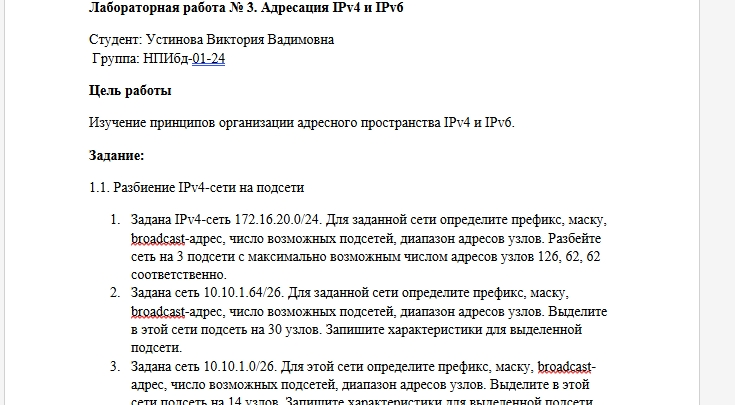

Описание работы, цели, задание, автор-я

## Задача 1 сеть 172.16.20.0/24 основные характеристика

Для сети 172.16.20.0/24 определить префикс маску broadcast-адрес, и диапазон узлов

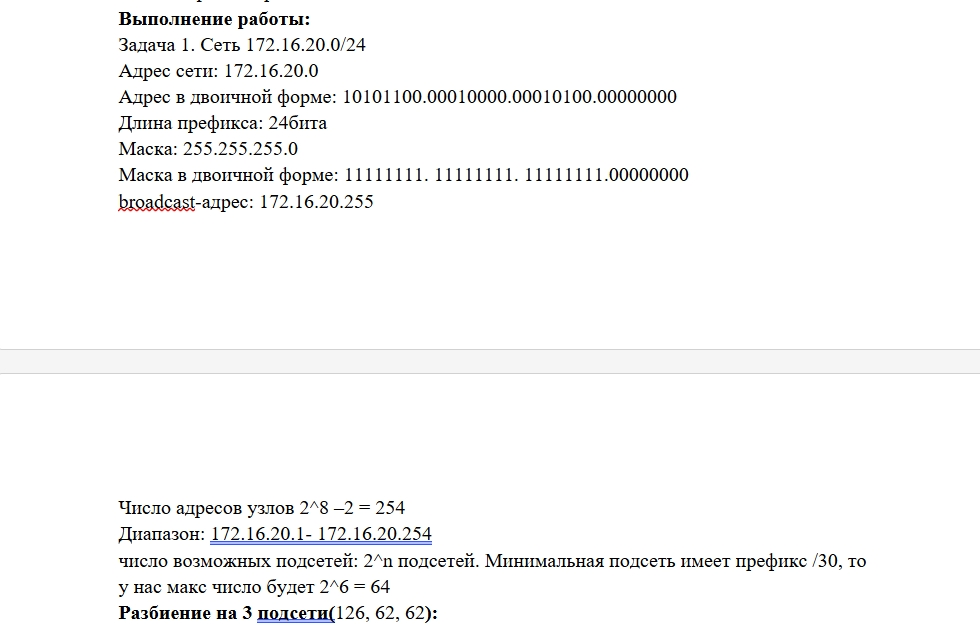

Префикс /24 маска 255.255.255.0 broadcast-адрес 172.16.20.255, диапазон 172.16.20.1-172.16.20.254

## задача 1 разбиение на 3 подсети

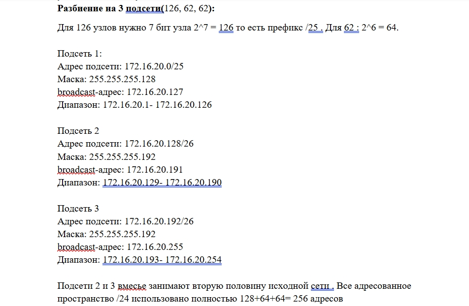

Для 126 узлов префикс /25, для 62 — /26. Подсети 172.16.20.0/25, 172.16.20.128/26 и 172.16.20.192/26. Пространство /24 использовано полностью

## Сеть 10.10.1.64/26 основные характеристики

Для сети 10.10.1.64/26 определить характеристики и выделить подсеть на 30 узлов

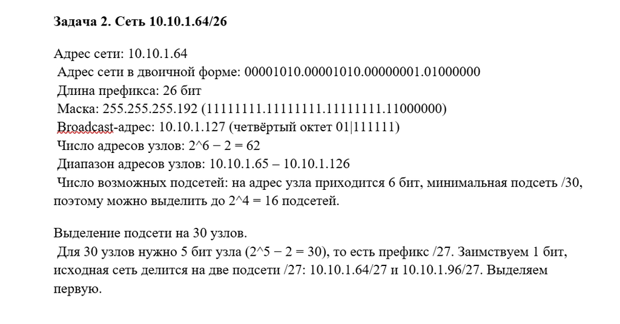

Маска 255.255.255.192, broadcast 10.10.1.127, диапазон 10.10.1.65–10.10.1.126. Для 30 узлов нужен префикс /27, заимствуется 1 бит.

## Задача 2. Выделение подсети на 30 узлов.

Записать характеристики выделенной подсети на 30 узлов

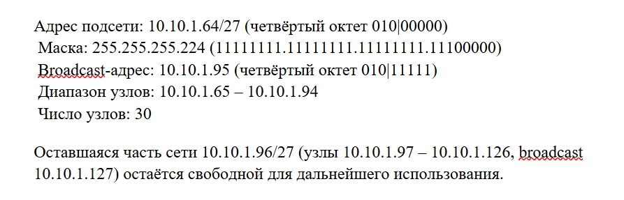

Подсеть 10.10.1.64/27, маска 255.255.255.224, broadcast 10.10.1.95, диапазон 10.10.1.65–10.10.1.94. Вторая половина 10.10.1.96/27 остаётся свободной.

## Задача 3. Сеть 10.10.1.0/26: разбиение на подсеть 14 узлов.

Для сети 10.10.1.0/26 определить характеристики и выделить подсеть на 14 узлов.

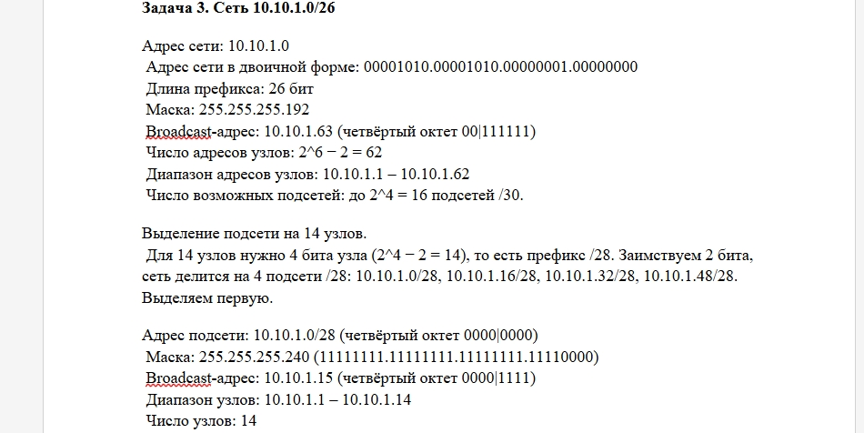

Маска 255.255.255.192, broadcast 10.10.1.63, диапазон 10.10.1.1–10.10.1.62. Для 14 узлов нужен префикс /28, заимствуется 2 бита. Подсеть 10.10.1.0/28, маска 255.255.255.240, broadcast 10.10.1.15, диапазон 10.10.1.1–10.10.1.14.

## Задача 4. Сеть 2001:db8:c0de::/48: характеристики.

Охарактеризовать адрес 2001:db8:c0de::/48.

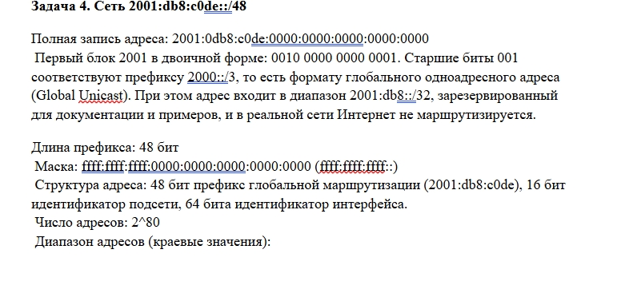

Global Unicast, зарезервирован для документации. Префикс /48, маска ffff:ffff:ffff::. Диапазон адресов: 2001:db8:c0de:0:0:0:0:0 — 2001:db8:c0de:ffff:ffff:ffff:ffff:ffff.

## Задача 4. Способ 1: разбиение по идентификатору подсети.

Разбить сеть 2001:db8:c0de::/48 на 2 подсети по идентификатору подсети

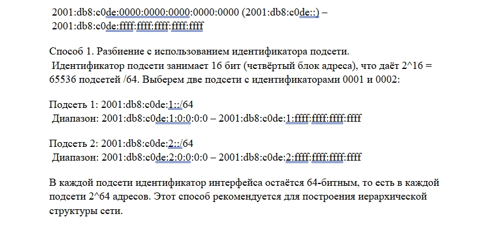

Идентификатор подсети занимает 16 бит (четвёртый блок), всего 2^16 подсетей /64. Выбраны подсети 2001:db8:c0de:1::/64 и 2001:db8:c0de:2::/64, по 2^64 адресов в каждой.

## Задача 4. Способ 2: разбиение по идентификатору интерфейса.

Разбить сеть 2001:db8:c0de::/48 на 2 подсети по идентификатору интерфейса

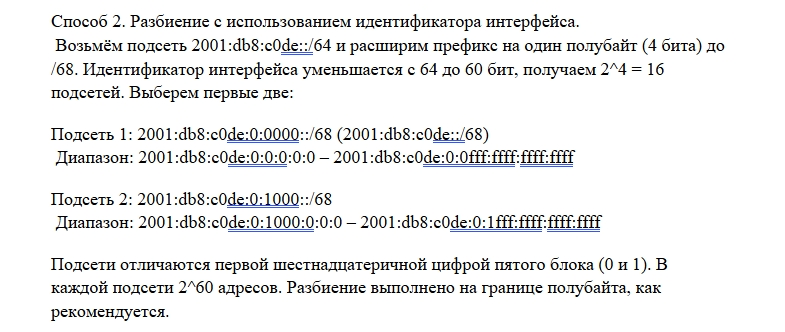

Префикс расширен на 4 бита до /68, идентификатор интерфейса уменьшен до 60 бит. Подсети 2001:db8:c0de:0:0000::/68 и 2001:db8:c0de:0:1000::/68, по 2^60 адресов.

## Задача 5. Сеть 2a02:6b8::/64: характеристики.

Охарактеризовать адрес 2a02:6b8::/64.

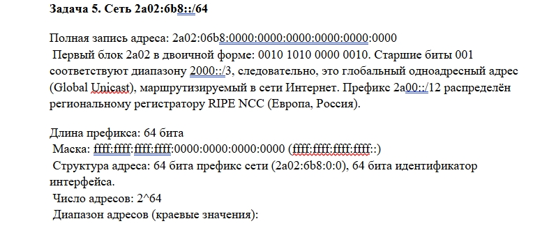

Global Unicast, префикс 2a00::/12 распределён RIPE NCC. Префикс /64, маска ffff:ffff:ffff:ffff::. Диапазон: 2a02:6b8:0:0:0:0:0:0 — 2a02:6b8:0:0:ffff:ffff:ffff:ffff.

## Задача 5. Способ 1: разбиение по идентификатору подсети.

Разбить сеть 2a02:6b8::/64 на 2 подсети по идентификатору подсети.

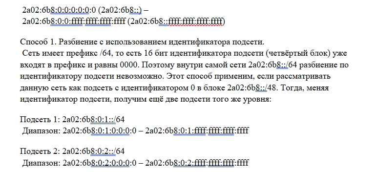

Внутри сети /64 разбиение невозможно, так как идентификатор подсети уже входит в префикс. Сеть рассматривается как подсеть с идентификатором 0 в блоке /48. Подсети 2a02:6b8:0:1::/64 и 2a02:6b8:0:2::/64.

## Задача 5. Способ 2: разбиение по идентификатору интерфейса.

Разбить сеть 2a02:6b8::/64 на 2 подсети по идентификатору интерфейса.

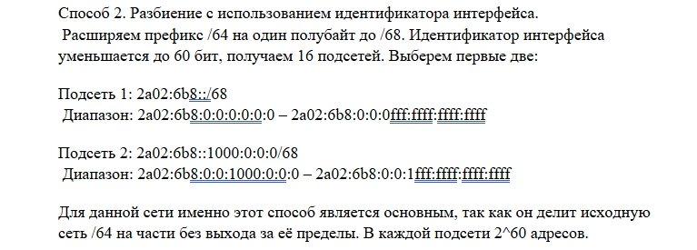

: Префикс расширен до /68, идентификатор интерфейса уменьшен до 60 бит. Подсети 2a02:6b8::/68 и 2a02:6b8::1000:0:0:0/68, по 2^60 адресов. Этот способ основной для данной сети.

## Выводы

В ходе работы были изучены принципы организации адресного пространства IPv4 и IPv6. Освоены методы разбиения сетей на подсети с использованием VLSM, определены префиксы, маски, broadcast-адреса и диапазоны узлов. Изучены способы разбиения IPv6-сетей по идентификатору подсети и по идентификатору интерфейса.

## Литературный список

1. RFC 1009. Requirements for Internet Gateways. — 1987.
2. RFC 1888. OSI NSAPs and IPv6. — 1996.
3. RFC 4291. IP Version 6 Addressing Architecture. — 2006.
4. Королькова А. В., Кулябов Д. С. Сетевые технологии. Лабораторный практикум.
5. IANA. IPv6 Address Space. — URL: https://www.iana.org/assignments/ipv6-address-space/